# LexLab Analysis Scaffolding

Matt Wagers

1/29/2021

# Set-up Chunks

### Session Options

Setting up libraries and options. This tutorial uses libraries from the `tidyverse` family so install that library.

```r
knitr::opts_chunk$set(echo = TRUE)
options(digits = 2)

library(tidyverse)
filter <- dplyr::filter
library(magrittr)
```

# Data Import, Cleaning and Checking

## Import Data from Ibex

The script `LexDec.js` has an unusually simple structure: each line contains information about a single trial[^1]. We can use the function `read_csv` to import these data.

In this function, we first create a vector containing column names. Many of these are not of use to us, or contain null or redundant info.

```r
# define column names [indicated by comments in datafile]
OnlineJudgment.cdef <- c("time","IPMD5","controller", "item","element","type","group","wnum","word","RT","key","newline","stim")

raw_results.tbl <- readr::read_csv("sample_results.csv",
                                   comment = "#", col_names = OnlineJudgment.cdef)
head(raw_results.tbl)
```

```
## # A tibble: 6 x 13
##     time IPMD5 controller  item element type  group  wnum word     RT key
##    <dbl> <chr> <chr>      <dbl>   <dbl> <chr> <chr> <dbl> <chr> <dbl> <chr>
## 1 1.61e9 7872… OnlineJud…    20       0 word… NULL      1 CINA…   976 K
## 2 1.61e9 7872… OnlineJud…    19       0 word… NULL      1 GLEE…  1201 K
## 3 1.61e9 7872… OnlineJud…     8       0 word… NULL      1 TWEL…   605 S
## 4 1.61e9 7872… OnlineJud…    14       0 word… NULL      1 GILA…   538 K
## 5 1.61e9 7872… OnlineJud…     7       0 word… NULL      1 GROW…   528 S
## 6 1.61e9 7872… OnlineJud…     4       0 word… NULL      1 GHOU…   549 S
## # … with 2 more variables: newline <lgl>, stim <chr>
```

Let’s clean up our columns and drop those we don’t need.

```r
# Combining time and IPMD5 gives us a way of creating unique participant identifier
# the following function 'pastes' those two columns together, and then hashes them to create an anonymous code

createUniqueParticipantIdentifier <- function(ibex.tbl){
  ibex.tbl$participant <- sapply(paste(ibex.tbl$time,
                                 ibex.tbl$IPMD5),
                           digest::digest, algo="md5")
  return(ibex.tbl)
}

# Apply the CUPI function and then deselect the columns we don't need
# Let's also rename the "RT" column to "LDT" to remind us what it really is ... "lexical decision time"
deselect_cols.vec <- c("time", "IPMD5", "controller", "element", "group", "wnum", "newline", "stim")

compact_results.tbl <- raw_results.tbl %>%
  createUniqueParticipantIdentifier %>%
  select(-all_of(deselect_cols.vec)) %>%
  rename(LDT = RT)

head(compact_results.tbl)
```

```
## # A tibble: 6 x 6
##    item type         word     LDT key   participant
##   <dbl> <chr>        <chr>  <dbl> <chr> <chr>
## 1    20 words-fake   CINALS   976 K     81b69145a3b2f05a0dbef0e5e50292ee
## 2    19 words-fake   GLEEDS  1201 K     81b69145a3b2f05a0dbef0e5e50292ee
## 3     8 words-hifreq TWELVE   605 S     81b69145a3b2f05a0dbef0e5e50292ee
## 4    14 words-fake   GILATE   538 K     81b69145a3b2f05a0dbef0e5e50292ee
## 5     7 words-hifreq GROWTH   528 S     81b69145a3b2f05a0dbef0e5e50292ee
## 6     4 words-lofreq GHOULS   549 S     81b69145a3b2f05a0dbef0e5e50292ee
```

## Check distribution of trials

Before proceeding to any analysis of the dependent variables of interest, we should always check that our scripts were functioning as we wanted them to.

Minimally, we want to check that we collected the right distribution of trials per participant and per condition. We can also check the distribution of RTs and overall “correctness.”

```r
# use the table command to create a contingency table, and the `%$%` operator to "expose" the columns of the target .tbl
cond_by_participant.table <- compact_results.tbl %$% table(participant, type)

# add margins and print to check
cond_by_participant.table %>% addmargins()
```

```
##                                   type
## participant                        words-fake words-hifreq words-lofreq  Sum
##   05aad3e7517cedfac820a536eaad19f4         10            5            5   20
##   075748ad8e962b20eaff4c6c931473f4         10            5            5   20
##   151459555623832a536c5e7c7da3c4aa         10            5            5   20
##   1768d687d489747280cb3bd741f6ffcb         10            5            5   20
##   191873e39bbcda2cf37d7ad9da510ab2         10            5            5   20
##   38194cc9bf1c89c2a5fefe945a6d580a         10            5            5   20
##   38342fd8f483a6d595cfdb8ee4b39a2e         10            5            5   20
##   39d58183cd9e5615659a888cbbdbece3         10            5            5   20
##   3ee637a61fc4cb7edbe652d91a054798         10            5            5   20
##   42bceca97a7ae6f8b49c228dda7d98f3         10            5            5   20
##   4fe5c113773932790be2adb659a1f049         10            5            5   20
##   5134f0c73ae296805b40d80faeb3bae9         10            5            5   20
##   5b117d5bf0f5e151bbe3d6d4828b4565         10            5            5   20
##   5bfccc939a8a00d9adbdd3076988aae2         10            5            5   20
##   5e32e9acbc42d9f0ec9244b330023614         10            5            5   20
##   613b934f5854913977294bec0099dd83         10            5            5   20
##   6291bc47c720ee7a35eafb9c42fc12b3         10            5            5   20
##   65e419502ee950acabf666b5805421f9         10            5            5   20
##   663fb2ea856253ce88cfa76f2de76fab         10            5            5   20
##   6dbdefdacd954b5ce8a5c448645e0bde         10            5            5   20
##   6f82a2c2c28815148090e597f7d228be         10            5            5   20
##   705f7d692cb8b631912d59eb91e77f38         10            5            5   20
##   73cbe555b9796a2f341ee417b8d4b5ed         10            5            5   20
##   76a21b19c2e6a9473830e1170e870c46         10            5            5   20
##   77420d4c1964028f25840ec3df50351a         10            5            5   20
##   7b37305caba93ad4cbc765d2905ad108         10            5            5   20
##   7d0ec1ae4919f150d391adb0b7aaed99         10            5            5   20
##   7f4130e2c2fe830c0e2678f06071164f         10            5            5   20
##   81b69145a3b2f05a0dbef0e5e50292ee         10            5            5   20
##   825a7f74bf672915174a5892721509f5         10            5            5   20
##   83603cea027f3bd0f5c16c0dfb1aa2fe         10            5            5   20
##   867165a8258ed283227355ed8ed71f1a         10            5            5   20
##   896477ed534bd0aac4ac171133160eac         10            5            5   20
##   8a3ff4729132afd39c0a2b305d813b9d         10            5            5   20
##   8d20be5db0b8fa1babe1d0fa81bafbad         10            5            5   20
##   8f12883d8496cb4650381b4eeefecbb8         10            5            5   20
##   9276f18dde096bfff8496ab0c83018e1         10            5            5   20
##   936f2e609ed1e8bc96a106691f6af3ec         10            5            5   20
##   a25c17412016f8549a6bd512ee7264e8         10            5            5   20
##   a73c6f75bfa6489524d9df4bb760d856         10            5            5   20
##   b0fb6a32968bd579677bc8be8c45455b         10            5            5   20
##   b2095da4e0f34b660ffd2d0240f177ce         10            5            5   20
##   bb265f895b38880cba7d3317170afe60         10            5            5   20
##   bc15f12d36ebf429a5b66cf64a24b322         10            5            5   20
##   d37f25406442423b53a59a7d368640d8         10            5            5   20
##   d44f6879f81ea517bfda796185446564         10            5            5   20
##   d5a8806736792c20fa31c2270982ea30         10            5            5   20
##   d71fc82f11304a0d91ac95a394a381df         10            5            5   20
##   e7476636290c0440cdbd425cc3e576a7         10            5            5   20
##   e86337e53a065624069465405418412c         10            5            5   20
##   eb198c187a621f23edb1b145a7c52f4e         10            5            5   20
##   ee944e7ae9a2b8ff9822ec271c07426b         10            5            5   20
##   f18c7348832bf439061e1a95ef1d1d85         10            5            5   20
##   f21e44f4323780b7a2ba4d0697ead9ae         10            5            5   20
##   f9a3161c8b45b265413a7f7e39f2744c         10            5            5   20
##   fd7a30b4467e19796a6eda34028045e6         10            5            5   20
##   Sum                                     560          280          280 1120
```

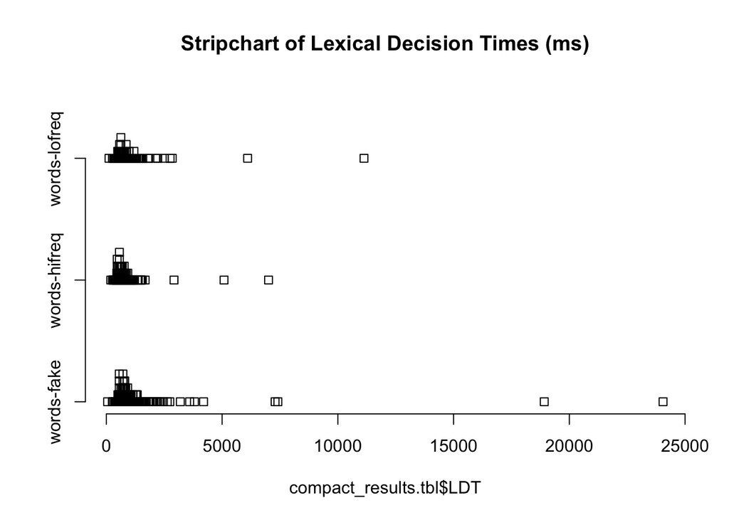

```r
# plot the distribution of LDTs
# many ways to plot

# stripchart method
stripchart(compact_results.tbl$LDT ~ compact_results.tbl$type, frame.plot=FALSE, method="stack", main="Stripchart of Lexical Decision Times (ms)")
```

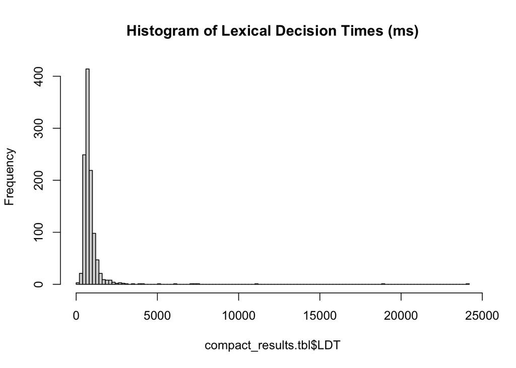

```r
# histogram
hist(compact_results.tbl$LDT, breaks=100, main="Histogram of Lexical Decision Times (ms)")
```

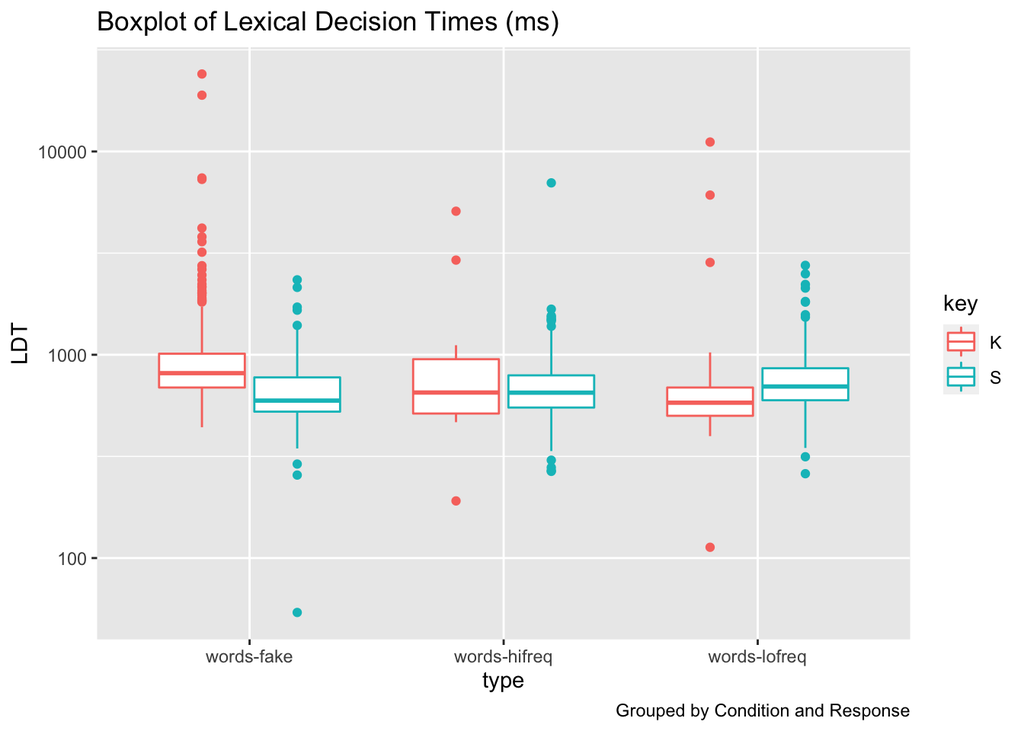

```r
# ggplot boxplot with log-10 axes
compact_results.tbl %>%
  ggplot(aes(x=type, y=LDT)) + geom_boxplot(aes(col=key)) + scale_y_log10() +
  labs(title="Boxplot of Lexical Decision Times (ms)", caption="Grouped by Condition and Response")
```

A few things become apparent:

- RTs have very long “right tail”. We didn’t timeout the response, so the trial wouldn’t advance until a key was pressed.
- the `key` variable isn’t very helpful

The right-tail problem for RT distributions is very problematic, because there is not a good way to identify outliers[^2]. We end up having to do something pretty arbitrary, more or less. Let’s “slice off” a slender tail at either end: 0.5% of the smallest observations, and 0.5% of the largest observations. This is reasonably conservative, but takes care of 24 sec LDTs …

```r
# first, determine the "cutoffs"
tails <- quantile(compact_results.tbl$LDT, c(0.005, 0.995))

# then, using filter to exclude, using the `between` boolean function
trimmed_LDT.tbl <- compact_results.tbl %>%
  filter(between(LDT, tails[1], tails[2]))

# double check we excluded the intended amount of data

excluded_pct <- 100 * (1-nrow(trimmed_LDT.tbl)/nrow(compact_results.tbl))
message(paste("Excluded", round(excluded_pct,1),"% of lexical decision times"))
```

```
## Excluded 1.1 % of lexical decision times
```

Now let’s solve the other problem: better labels for `key`

```r
# To solve this problem, we first create a translation key:
# the first column is the original names of `key`, the other column gives us new names
keycode.tbl <- tibble(key = c("K", "S"),
                      judgment = c("nonword", "word"))

# We then use a join command to match all rows from the left table with matching rows in the right table
trimmed_LDT.tbl <- left_join(trimmed_LDT.tbl, keycode.tbl)
# Use `head` to check it worked
head(trimmed_LDT.tbl)
```

```
## # A tibble: 6 x 7
##    item type         word     LDT key   participant                     judgment
##   <dbl> <chr>        <chr>  <dbl> <chr> <chr>                           <chr>
## 1    20 words-fake   CINALS   976 K     81b69145a3b2f05a0dbef0e5e50292… nonword
## 2    19 words-fake   GLEEDS  1201 K     81b69145a3b2f05a0dbef0e5e50292… nonword
## 3     8 words-hifreq TWELVE   605 S     81b69145a3b2f05a0dbef0e5e50292… word
## 4    14 words-fake   GILATE   538 K     81b69145a3b2f05a0dbef0e5e50292… nonword
## 5     7 words-hifreq GROWTH   528 S     81b69145a3b2f05a0dbef0e5e50292… word
## 6     4 words-lofreq GHOULS   549 S     81b69145a3b2f05a0dbef0e5e50292… word
```

```r
## You might want to use the same strategy to rename the "type" variable into two variables: "lexicality" and "frequency"

## We can use the -select command to get rid of the columns we know longer want ...
## ... this is destructive, so once it's run once the commands above won't work anymore
trimmed_LDT.tbl <- trimmed_LDT.tbl %>% select(-key)
head(trimmed_LDT.tbl)
```

```
## # A tibble: 6 x 6
##    item type         word     LDT participant                      judgment
##   <dbl> <chr>        <chr>  <dbl> <chr>                            <chr>
## 1    20 words-fake   CINALS   976 81b69145a3b2f05a0dbef0e5e50292ee nonword
## 2    19 words-fake   GLEEDS  1201 81b69145a3b2f05a0dbef0e5e50292ee nonword
## 3     8 words-hifreq TWELVE   605 81b69145a3b2f05a0dbef0e5e50292ee word
## 4    14 words-fake   GILATE   538 81b69145a3b2f05a0dbef0e5e50292ee nonword
## 5     7 words-hifreq GROWTH   528 81b69145a3b2f05a0dbef0e5e50292ee word
## 6     4 words-lofreq GHOULS   549 81b69145a3b2f05a0dbef0e5e50292ee word
```

With our neater dataset, let’s replot our LDT range:

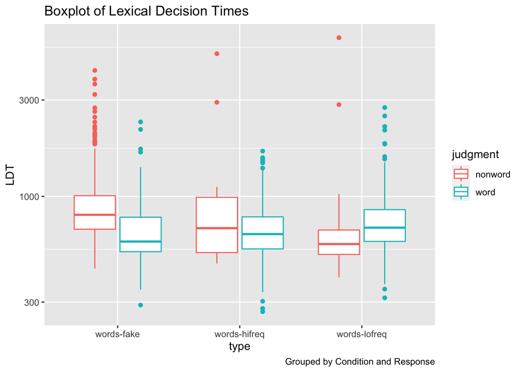

```r
# ggplot boxplot with log-10 axes
trimmed_LDT.tbl %>%
  ggplot(aes(x=type, y=LDT)) + geom_boxplot(aes(col=judgment)) + scale_y_log10() +
  labs(title="Boxplot of Lexical Decision Times", caption="Grouped by Condition and Response")
```

The center line in a boxplot is the median[^3]. Can you spot whether or not there’s a frequency effect in the correct judgment of real words? Let’s “regroup” to make it easier to spot … observe how I swap `judgment` and `type` in the ggplot call below (with respect to the calls in the above chunks). Note I also store the result.

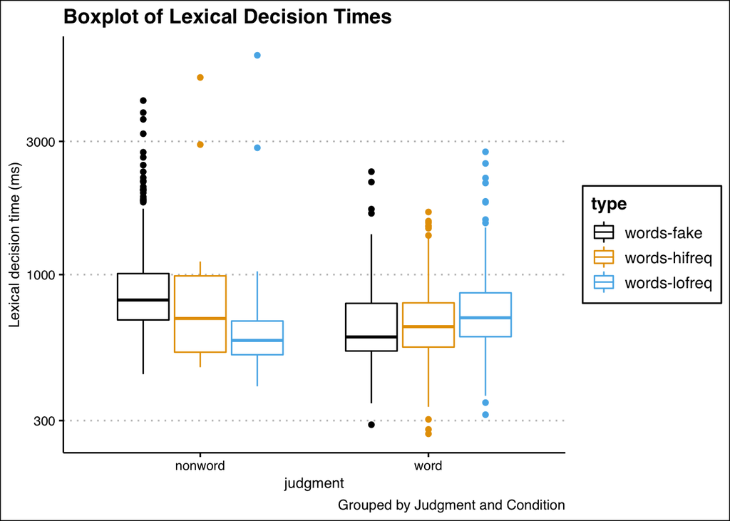

```r
trimmed_LDT.ggp <- trimmed_LDT.tbl %>%
  ggplot(aes(x=judgment, y=LDT)) + geom_boxplot(aes(col=type)) + scale_y_log10() +
  labs(title="Boxplot of Lexical Decision Times", caption="Grouped by Judgment and Condition")

# let's "print" it with some friendlier colors & themes ... and make sure we don't forget our units!
trimmed_LDT.ggp + ggthemes::theme_clean() + ggthemes::scale_color_colorblind() + ylab("Lexical decision time (ms)")
```

# Summarizing

## Accuracy

Here’s a simple view of accuracy. We use the `table` and `prop.table` commands to cross-classify and *condition* by *judgment* and then normalize…

```r
response.table <- with(trimmed_LDT.tbl, table(type, judgment))

response.table %>% addmargins()
```

```
##               judgment
## type           nonword word  Sum
##   words-fake       503   51  554
##   words-hifreq      12  265  277
##   words-lofreq      23  254  277
##   Sum              538  570 1108
```

```r
response.table %>% prop.table(1)
```

```
##               judgment
## type           nonword  word
##   words-fake     0.908 0.092
##   words-hifreq   0.043 0.957
##   words-lofreq   0.083 0.917
```

Notice that our margins aren’t as uniform as before, because we trimmed some LDTs.

This way of doing things is fine, but not very generalizable. For one thing, what counts as a “correct” response differs based on the type of word. There are a few strategies here. One uses `ifelse` statements.

```r
trimmed_LDT.tbl <- trimmed_LDT.tbl %>% mutate(correct = ifelse(type=="words-fake" & judgment=="nonword", TRUE,
                           ifelse(type!="words-fake" & judgment=="word", TRUE, FALSE)))

trimmed_LDT.tbl %$% table(type, correct) %>% prop.table(1)
```

```
##               correct
## type           FALSE  TRUE
##   words-fake   0.092 0.908
##   words-hifreq 0.043 0.957
##   words-lofreq 0.083 0.917
```

The `ifelse` method is clunky, fragile and hard-to-read. You should avoid it! It would be far better to use the more flexible and extensible `join` strategy from the `rename key` chunk above. Let’s create a *lexicality* variable and then use a Boolean expression to check for correctness.

```r
# create a lexicality.key
lexicality.tbl <- tibble(type = c("words-fake", "words-hifreq", "words-lofreq"),
                         lexicality = c("nonword", "word", "word"),
                         frequency = c("zero", "high", "low"))
# print it, to make sure it looks right
print(lexicality.tbl)
```

```
## # A tibble: 3 x 3
##   type         lexicality frequency
##   <chr>        <chr>      <chr>
## 1 words-fake   nonword    zero
## 2 words-hifreq word       high
## 3 words-lofreq word       low
```

```r
# left_join to insert `lexicality` into our data
trimmed_LDT.tbl <- left_join(trimmed_LDT.tbl, lexicality.tbl)
# Now, we can define `correct` as whether or not `judgment` and `lexicality` coincide3
trimmed_LDT.tbl <- trimmed_LDT.tbl %>% mutate(correct = (lexicality==judgment))

trimmed_LDT.tbl %$% table(correct, frequency, lexicality) %>% prop.table(c(2,3))
```

```
## , , lexicality = nonword
##
##        frequency
## correct high low  zero
##   FALSE          0.092
##   TRUE           0.908
##
## , , lexicality = word
##
##        frequency
## correct  high   low zero
##   FALSE 0.043 0.083
##   TRUE  0.957 0.917
```

Same result, much more elegant. This will allow us to easily compute LDTs on both correct and incorrect trials. Plus, Boolean variables can be treated arithmetically in a pinch (mapping TRUE/FALSE to 1/0). Notice how `ptable` in the chunk above is used to create proportions over multiple dimensions: *c(2,3)* refers to the 2nd and 3rd dimension of the table just created, i.e., *frequency* and *lexicality*.

Here is the `tidyverse` way of making a table like the above. As with `table` we group along the dimensions, but we explicitly call a counting function `n()` and compute the sums ourselves. We can filter to either *correct == FALSE* or *correct == TRUE* cases to generate the error rate or % correct rate, depending on how we want to report it.

```r
trimmed_LDT.tbl %>% group_by(lexicality, frequency, correct) %>%
  summarize(count = n()) %>% mutate(tot = sum(count), presp = count/tot) %>%
  filter(correct==FALSE)
```

```
## # A tibble: 3 x 6
## # Groups:   lexicality, frequency [3]
##   lexicality frequency correct count   tot  presp
##   <chr>      <chr>     <lgl>   <int> <int>  <dbl>
## 1 nonword    zero      FALSE      51   554 0.0921
## 2 word       high      FALSE      12   277 0.0433
## 3 word       low       FALSE      23   277 0.0830
```

## Lexical Decision time

```r
ldt_summary.tbl <- trimmed_LDT.tbl %>% group_by(lexicality, frequency, correct) %>%
  summarize(meanLDT = mean(LDT), sd = sd(LDT), N = n(), se = sd/sqrt(N))
```

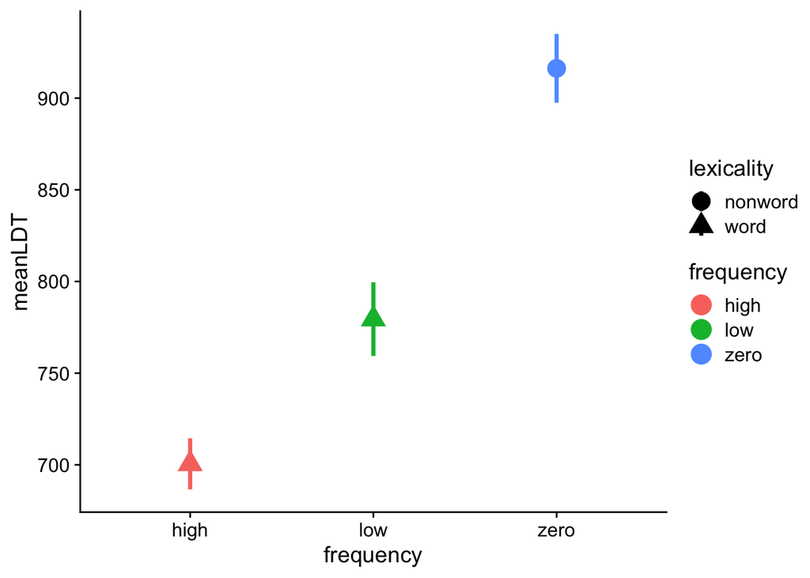

```r
ldt_summary.tbl %>% filter(correct==TRUE) %>% ggplot(aes(x = frequency, y = meanLDT, col=frequency, shape=lexicality)) +
  geom_pointrange(aes(ymin = meanLDT - se, ymax=meanLDT+se), size = 1.2,position = position_dodge(width = 0.2)) +
  cowplot::theme_cowplot()
```

```r
ggsave("lexdec-correct.pdf", width=6, height=4)
```

#### Standard deviations

By now, you’ve probably already been eyeing the patterns in the data tables. How can we know whether those differences reflect difference in the underlying processes of lexical access, and not random differences or errors due to our sampling procedure?

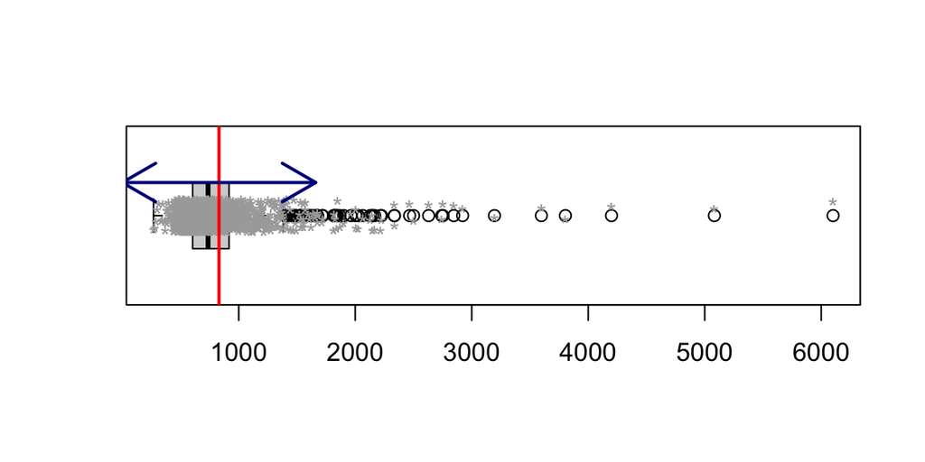

```r
boxplot(trimmed_LDT.tbl$LDT, horizontal=TRUE)
stripchart(trimmed_LDT.tbl$LDT, pch="*", method="jitter", col="darkgrey", add=TRUE)

LDT.mean <- mean(trimmed_LDT.tbl$LDT)
LDT.sd <- sd(trimmed_LDT.tbl$LDT)

# Mark the mean with a red line
abline(v = LDT.mean, lwd=2, col="red")

# Mark the SD with two blue arrows
arrows(x0 = LDT.mean, y0=1.2, x1 = LDT.mean+LDT.mean, y1=1.2, lwd=2, col="darkblue")
arrows(x0 = LDT.mean, y0=1.2, x1 = LDT.mean-LDT.mean, y1=1.2, lwd=2, col="darkblue")
```

Notice in this plot that the observations aren’t scattered evenly around the mean: this is because RTs are bounded to the left (e.g., they must be positive), but are effectively unbounded to the right. [Because of this: a better summary statistic for this data might be the median, but using the median, a so-called rank based statistic, will present its own set of challenges.]

OK, so let’s plot the condition-wise standard deviations, computed as part of the `summarize LDT` chunk. Here I will plot them with their means. Do you notice any pattern?

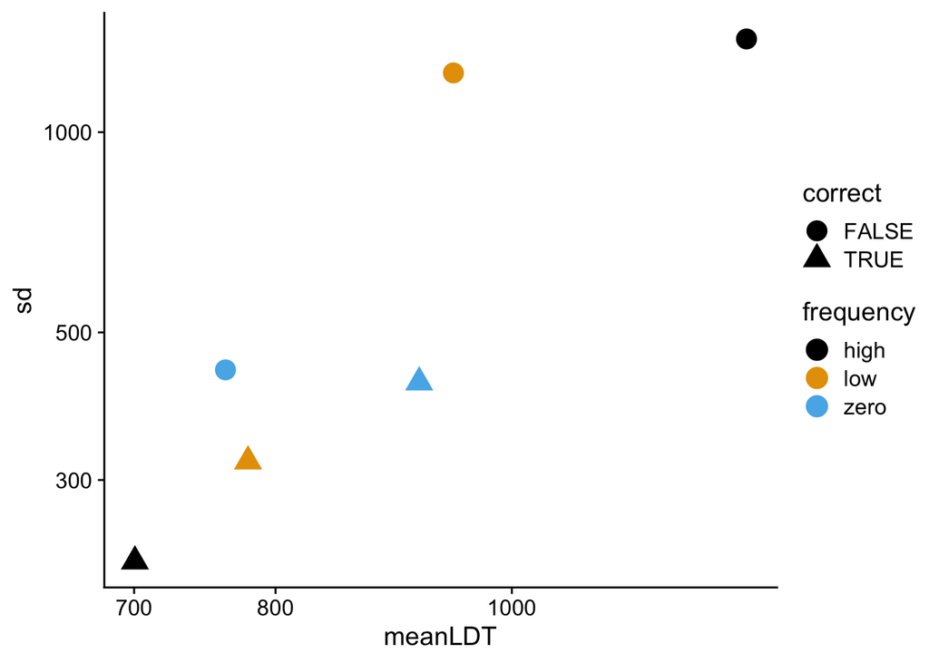

```r
ldt_summary.tbl %>%
  ggplot(aes(x = meanLDT, y=sd)) +
  geom_point(aes(col=frequency, shape=correct), size=5) + cowplot::theme_cowplot() +
  scale_x_log10() + scale_y_log10() +
  ggthemes::scale_color_colorblind()
```

We can see in which conditions there is greater scatter amongst the observations. In doing statistical inference, we use that scatter to estimate the range of results we might expect from replicating this experiment. Based on that estimate, we decide whether two means are significantly far apart from one another: if one mean falls within the other means range of replication, then it is risky to conclude that they are not merely different due to the inherent variation in the measurement/experimental design/number of subjects/number of items.

### Inferential statistics - first steps

Consider the factor *frequency*. Let’s ask whether frequency" “has an effect.”

First, compute the difference in high and low frequency words.

```r
rw_corr_means.tbl <- ldt_summary.tbl %>% filter(frequency %in% c("high", "low") & correct==TRUE)
print(rw_corr_means.tbl)
```

```
## # A tibble: 2 x 7
## # Groups:   lexicality, frequency [2]
##   lexicality frequency correct meanLDT    sd     N    se
##   <chr>      <chr>     <lgl>     <dbl> <dbl> <int> <dbl>
## 1 word       high      TRUE       701.  226.   265  13.9
## 2 word       low       TRUE       779.  320.   254  20.1
```

```r
# What is the difference between hi and lo frequency?
rw_freq_effect <- rw_corr_means.tbl$meanLDT %>% diff
print(rw_freq_effect)
```

```
## [1] 79
```

To know whether that the difference observed, 78.95, could be explained by inherent variation in experiments like the one we just conducted, we must now estimate the range of likely outcomes. This is related to the sample standard deviation, via what’s known asthe *standard error*. The standard error is the standard deviation, not of the sample, but of the sample mean. You can think of this in a few ways: one, as the standard deviation of a set of means from a series of identical experiments; or two, as the variability in means if we randomly drop certain trials and replace them with others.

We already computed SE in the `summarize LDT` chunk. (See above)

To test the contrast of frequency in just the words (or just the non-words), we combine the two standard errors in a way that’s weighted by the number of observations. We’ll let R do that for us via the `t.test` command below.

#### Excursus I: central limit theorem

With the standard error in hand, we now consider the central limit theorem. The central limit theorem tells us that the distribution of means tends in the limit toward a special distribution: the Normal distribution. Among the important properties of the Normal are its symmetry and the fact it can be specified just by a standard deviation and mean. Suppose we repeatedly drop/replace trials in our dataset with other trials and recomputing the mean each time. If we do this, we will derive a normal distribution (notice that it is symmetric and *not* positively-skewed, like the sample distribution of RTs; that’s because it’s not a distribution of RT observations, but a distribution of means over those observations).

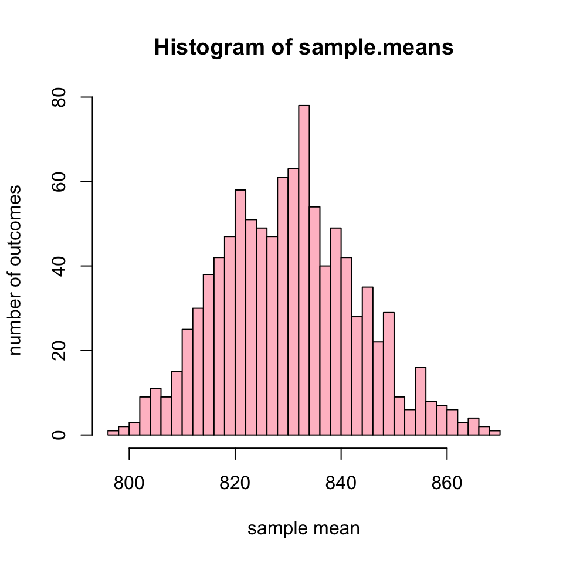

```r
# This demo will "resample"" the experiment; that is: drop some observations and replacing them by duplicating others.
# Let's do it 500 times and keep track of the results

# This vector will store our results
sample.means <- vector(mode="double", length=1000)

# This loop will repeat 1000 times
reps <- 1E3

for(i in 1:reps){
  # sample reconstitutes the sample by drawing from the set of observations with replacement (can draw the same obs again)
  resample.experiment <- sample(trimmed_LDT.tbl$LDT, replace=TRUE)
  mean(resample.experiment) -> sample.means[i]
}

# Draw a histogram of 500 outcomes
hist(sample.means, breaks=50, xlab="sample mean", ylab="number of outcomes", col="pink")
```

Crucially, observe that the mean of this, the so-called `sampling distribution`, is 830.07, which is the almost identical to the empirically observed grand mean 830.46. And the standard deviation of this distribution, 12.96 is very close to the empirical standard error: 12.88. The importance of the central limit theorem is that it allows us make a good estimate of the sampling distribution, based on our observations alone.

#### Confidence interval & t-test

In a normal distribution, 95% of the values falls between (roughly) 2 times the standard deviation in either direction from the mean (the actual multiplier is closer to 1.96). So we can establish a 95% ‘confidence interval’ of means that we expect just via the process of sampling.

The confidence interval tells us how much risk comes with accepting our estimate of some effect. Intuitively we can think of them as a plausible range of values for the “true” difference in the population between lexical decision times to our set of high and low frequency words. But more accurately, we can think of CIs as a statement of how good of an estimate we made. What is the chance of us getting the wrong idea about the true effect? Notice that the higher we raise the confidence level C, the wider our boundaries get: we’re willing to tolerate less risk in our estimate of the population value, so we make it harder and harder for it to fall outside our interval. In psycholinguistics, the 95% C.I. is commonly used.

In the calculations below, we calculate the confidence interval on the overall mean:

```r
options(digits=3)
# approximate calculation
LDT.mean <- mean(trimmed_LDT.tbl$LDT)
LDT.se <- sd(trimmed_LDT.tbl$LDT)/sqrt(length(trimmed_LDT.tbl$LDT))
c(LDT.mean - 2*LDT.se, LDT.mean + 2*LDT.se)
```

```
## [1] 805 856
```

```r
# less approximate calculation
n <- length(trimmed_LDT.tbl$LDT)
conf.int <- qnorm(0.975)*LDT.se
c(LDT.mean - conf.int, LDT.mean + conf.int)
```

```
## [1] 805 856
```

```r
# exact calculation
t.test(trimmed_LDT.tbl$LDT)$conf.int
```

```
## [1] 805 856
## attr(,"conf.level")
## [1] 0.95
```

However, to test the difference between any two means, we can ask: does the difference between two means exceed a confidence interval on their differences? To do this, we need to know: the empirical value of the two means, their standard deviations, and the number of observations. When the number of observations is small, we have to ‘inflate’ the multiplier on the standard error to account for the extra uncertainty in the quality of our estimate – this effectively admits that more observations might fall in the tails of the distribution than we think. To do this, we use the so-called `t-distribution`.

```r
confidence.level <- .05

qt(1-(confidence.level/2), df = length(trimmed_LDT.tbl$RT-1))
```

```
## [1] NaN
```

Based on the t-distribution, we can apply a `t-test` to compare two sample means, and determine whether they are different from one another, beyond just what we’d expect from sampling - i.e., is one mean outside ~2x the sampling distribution of the other mean. Although it’s possible to do this by hand, we can use R’s built in `t.test()` function to compute the two means, and the confidence interval over thei difference. It’s better to use the in-built function, because it makes a number of correction for important factors not discussed here (for brevity and clarity’s sake). Suffice it to say that the definition of standard error - and the quantity called the degrees of freedom - changes if different numbers of observations go into each mean, if different conditions have unequal variances, etc. [almost always the case for RTs].

Let’s demonstrate this for the effect of frequency on words:

```r
options(digits=5)
# Dependent variable is expressed to the left of ~, variable you're testing to the right
frequency.t_test <- trimmed_LDT.tbl %>% filter(lexicality=="word") %$%
  t.test(LDT ~ frequency)

# Specified alternatively
with(trimmed_LDT.tbl, t.test(LDT[frequency=="high"], LDT[frequency=="low"]))
```

```
##
##  Welch Two Sample t-test
##
## data:  LDT[frequency == "high"] and LDT[frequency == "low"]
## t = -1.93, df = 526, p-value = 0.054
## alternative hypothesis: true difference in means is not equal to 0
## 95 percent confidence interval:
##  -139.2766    1.1033
## sample estimates:
## mean of x mean of y
##    724.25    793.33
```

This outputs a lot of useful information. Focusing on the 95% confidence interval, we see that it contains the empirical difference, -69.08664. Crucially, observe that the confidence interval **does include 0**. Based on this fact, we would not call the difference *significant* at the conventional level (*p < .05*). Because the confidence interval included 0, then the natural variation in the sampling procedure (given our sample size, our participants, etc.) is deemed *by convention* sufficient to explain the observed difference. (There is nothing mathematically important about the number 95% - it is a convention. We can apply a stricter or a looser standard, if we’d like. In this case, it also happens to be conventional to refer to the result as marginally significant (*p < .10*. But I underscore the word *conventional*.)

Above the confidence interval there are three numbers: `t`, `df` and `p-value`. The t-value expresses the difference between the means normalized against the standard error (adjusted because of unequal sample sizes and unequal sample standard deviations). It is useful to express the number in this way, because, if its absolute value is greater than ~2, then the confidence interval probably doesn’t include 0. The p-value tells us actually how far out into the tails of the t-distribution we have to go to find our observed difference. Crucially, to correspond to a 95% confidence interval, it has to be less than .05.

Given all of this, we could report in a write-up, something like,

> There was a marginally significant effect of frequency: lexical decisions to high frequency words were faster than to low frequency words, by 69 ms (Welch’s two-sample t = -1.93, df = 526, p = 0.054).

There is a standard practice is to report the p-value as an inequality along the following scale: “.10 > .05 > .01 > .005 > .001”. There is nothing deep about it; and in fact, you should know that it is in many ways unsatisfactory. Report exact p-values.

Alternatively, you can report the mean difference and its confidence interval:

[output not shown]

[If you’re following along the .Rmd document, you will notice I’m inserting those values in-line in the text, not just copy-and-pasting them from the analysis output. Observe, while you’re at it, that the units are reported].

##### Demonstration by simulation

Probably you have a headache by now, but let’s just show that the results of a simulation in which we resample the data will generate a similar result. In other words, we take out some observations and replace them with others (randomly) - and then compute the difference according to frequency. Skip this if you like.

```r
# Create a vector to hold the result of each 're-sample'
differences.vector <- vector(mode="double", length=500)
# Unique trial IDs
real_words.tbl <- filter(trimmed_LDT.tbl, lexicality=="word")
observations <- 1:nrow(trimmed_LDT.tbl)

for(i in 1:1000){
  # Sample from the trial IDs
  resample.index <- sample(observations, replace=TRUE)
  # Take the difference across means according to frequency, using the resample index
  differences.vector[i] <- diff(with(real_words.tbl[resample.index,], tapply(LDT, frequency, mean))[1:2])
}
# Summary stats of difference vector
mean(differences.vector)
```

```
## [1] 68.95
```

```r
quantile(differences.vector, c(0.025, .975))
```

```
##     2.5%    97.5%
##   1.1447 144.4786
```

The `quantile` command lets us find out where the central 95% of the distribution lines – thus directly computing the confidence interval. How does the resampled interval compared with the t-test? [You may want to run the simulation a few times.]

### Graphing

What you should take away from the above: the standard deviation of a sample/condition/contrast tells us valuable information about how precisely we can resolve differences between two values. We can convey this information succintly by using *error bars* on a graph. Review the `visualize LDT` chunk above for how to accomplish this with `ggplot`.

The advantage of having these standard-error-sized error bars is that I can imagine doubling them for any given bar, and then seeing whether it overlaps with the height of another bar. This is a quick-and-dirty (i.e., adequate, not perfect) way of gauging whether a difference is significant, without consulting the text.

### To come

OK, this is enough to handle for now. Congratulations on finishing this document!

- In the next lab, we’ll talk about the very important topic of how to handle subject and item variability. The application of a simple two-sample t-test is really inappropriate, since it assumes the two conditions were sampled independently - but, in fact, they came from the same individual! For now, though, we’ll elide over this important feature of our data set … a feature which pervades almost all (psycho)linguistic data.

#### Excursus II: T-test by simulation

Let’s demonstrate by simulation how the results of the t-test can be obtained.

```r
# Subset out the RTs for hi and lo freq words, respectively
subset(real_words.tbl, frequency=="high")$LDT -> hifreq.population
subset(real_words.tbl, frequency=="low")$LDT -> lofreq.population

# Create a vector to hold the sample differences
vector(mode="double", length=1000) -> sample.differences

# Repeat loop - each time, for the hi and lo freq RTs, drop some and replace with duplicates of others
for(i in 1:1000){
  hifreq.sample <- sample(hifreq.population, replace=TRUE)
  lofreq.sample <- sample(lofreq.population, replace=TRUE)

  # compute the difference between the means of these resampled RTs
  sample.differences[i] <- mean(hifreq.sample) - mean(lofreq.sample)
}

# What's the range of the middle 95% of values of sample differences?
quantile(sample.differences, c(0.025, 0.975))
```

```
##       2.5%      97.5%
## -140.74052    0.11769
```

```r
# How does this compare to the t-test result?
print(frequency.t_test$conf.int)
```

```
## [1] -139.2766    1.1033
## attr(,"conf.level")
## [1] 0.95
```

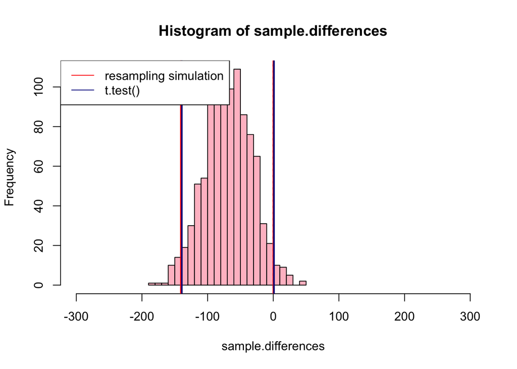

```r
# Draw a histogram to illustrate
hist(sample.differences, breaks=20, col="pink", xlim=c(-300, 300))
# Mark 0
abline(v=0, lty="dotted", lwd=2, col="darkgrey")
# Resampling confidence interval in red
abline(v = quantile(sample.differences, c(0.025, 0.975)), col="red", lwd=2)
# T-test conf. int. in blue
abline(v = frequency.t_test$conf.int, col="darkblue", lwd=2)
legend(x = "topleft", legend=c("resampling simulation", "t.test()"), lty="solid", col=c("red", "darkblue"))
```

# References

Baayen, R. H., & Milin, P. (2010). Analyzing reaction times. *International Journal of Psychological Research*, *3*(2), 12–28.

Lo, S., & Andrews, S. (2015). To transform or not to transform: Using generalized linear mixed models to analyse reaction time data. *Frontiers in Psychology*, *6*, 1171. https://doi.org/10.3389/fpsyg.2015.01171

Ratcliff, R. (1993). Methods for dealing with reaction time outliers. *Psychological Bulletin*, *114*(3), 510–532.

[^1]: This isn’t the “norm” with Ibex, which lets each controller in your experiment write a line per trial. However, the template `LexDec.js` only used one controller: OnlineJudgment. There wasn’t even a form to collect demographic information or debriefing info.
[^2]: Many have grappled with this! Ratcliff (1993) is a classic starting point. More recently Baayen & Milin (2010) and Lo & Andrews (2015) have pursued model-based solutions.
[^3]: Good time to read up on [boxplots](https://en.wikipedia.org/wiki/Box_plot)!